# Trabalho Prático 1- Análise de Clusters

Universidade do Minho

Grupo 4

20/novembro/2019

## **Dataset Real State Sample**

A base de dados utilizada neste trabalho é uma amostra aleatória de 1200 casas situadas em Saratoga, New York. Estão envolvidas 10 variáveis. Destas, 7 são variáveis numéricas, como o preço da casa, a idade, a área útil, o número de casas de banho privadas e de serviço, o número de quartos e o número de lareiras. As restantes 3 são variáveis nominais, sendo exemplo, a proximidade do mar, a existência de aquecimento central e o tipo de combustível utilizado na casa.

De seguida está presente uma breve descrição das variáveis:

- **Sale Price**: preço da casa em dólares;
- **Waterfront**: se a casa está perto de zonas marítimas;
- **Age**: idade da casa (anos);
- **Central air**: se a casa tem ar central;
- **Fuel Type**: combustível usado para aquecimento (3 tipos - “electric”, “oil”, “gas”);
- **Living Area**: área da casa (square feet);
- **Full Baths**: Número de casas de banho completas;
- **Half Baths**: Número de casas de banho de serviço (sem chuveiro ou banheira);
- **Bedrooms**: Número de quartos;
- **Fireplaces**: Número de lareiras existentes na casa.

O objetivo deste trabalho é explicar o preço das casas na cidade de Saratoga pelas variáveis água, idade, ar central, tipo de combustível, área da casa, casas de banho completas, casas de banho de serviço, quartos e lareiras.

# Descrição das variáveis envolvidas

#### **Variável dependente**

Uma variável dependente é uma medida que dependerá do valor de outra(s) medida variável. Na base de dados apresentada, o preço de venda das casas, em dólares, é considerada a variável dependente, uma vez que depende das restantes variáveis. Esta é uma variável quantitativa discreta.

```r
#variável dependente
preco<-DadosTP$`Sale Price`
```

#### **Variáveis independentes**

Uma variável indenpendente é uma medida que não depende de nenhuma outra medida, sendo que existem 9 variáveis deste tipo no modelo. As variáveis podem ser quantitativas e qualitativas. Quanto às variáveis quantitativas, nesta base de dados, apenas existem variáveis discretas (idade, areacasa, wcprivado, wcservico, quartos, lareira). Relativamente às variáveis qualitativas, existem 3 variáveis nominais - arcentral, tipocombustivel e agua.

```r
#variáveis independentes
agua<-DadosTP$Waterfront
idade<-DadosTP$Age
arcentral<-DadosTP$`Central Air`
tipocombustivel <- DadosTP$`Fuel Type`
areacasa<-DadosTP$`Living Area`
wcprivado<-DadosTP$wcprivado_agre
wcservico<-DadosTP$`Half Baths`
quartos<-DadosTP$quartos_agr
lareira<-DadosTP$lareira_agre
```

Depois de analisar os dados, constatou-se que na variável “tipocombustivel” existiam dois tipo de combustível (“propane” e “wood”) com apenas 2 observações cada, em 1200 observações. Assim, esses dois foram eliminados de forma a evitar conflitos uma vez que, como estes valores são muitos pequenos, poderiam trazer complicações ao modelo.

### Criação das variáveis como fator

Uma vez que na base de dados existem 3 variáveis nominais foi necessário criar fatores para as 3. Os fatores são usados para categorizar os dados e armazená-los como níveis, podendo armazenar sequências de carateres e números inteiros. São úteis em casos como este, em que as colunas possuem um número limitado de valores exclusivos, como “Yes” e “No”, ou os 3 tipos de combustíveis.

Para criar as variáveis como fator utilizou-se a função “factor”, em que o único argumento necessário é um vetor de valores. O argumento “levels” determina as categorias da variável fator, e o padrão é a lista de todos os valores distintos do vetor de dados.

```r
#criação das variáveis como fator
agua.f <- factor(agua)
arcentral.f  <- factor(arcentral)
tipocombustivel.f <- factor(tipocombustivel)

levels(agua)<-c("Yes","No")
levels(arcentral)<-c("Yes","No")
levels(tipocombustivel)<-c("Oil","Gas", "Electric")

is.factor(tipocombustivel)
```

```
## [1] FALSE
```

```r
# número de vezes que cada variável aparece
tabulate(agua.f)
```

```
## [1] 1194    2
```

```r
tabulate(arcentral.f)
```

```
## [1] 711 485
```

```r
tabulate(tipocombustivel.f)
```

```
## [1] 134 168 894
```

```r
summary(agua.f)
```

```
##   No  Yes
## 1194    2
```

```r
summary(arcentral.f)
```

```
##  No Yes
## 711 485
```

```r
summary(tipocombustivel.f)
```

```
## Electric      Gas      Oil
##      134      168      894
```

# Análise Descritiva

Utilizando a função “summary” verificamos o mínimo, máximo, a mediana e os quartis para cada variável em estudo.

```r
#summary dos dados
summary(DadosTP)
```

```
##    Sale Price       Waterfront             Age         Central Air
##  Min.   :  30000   Length:1196        Min.   :  0.00   Length:1196
##  1st Qu.: 150000   Class :character   1st Qu.:  4.00   Class :character
##  Median : 199700   Mode  :character   Median : 17.00   Mode  :character
##  Mean   : 226025                      Mean   : 24.39
##  3rd Qu.: 275000                      3rd Qu.: 30.00
##  Max.   :1155000                      Max.   :227.00
##   Fuel Type          Living Area     Full Baths      Half Baths
##  Length:1196        Min.   : 375   Min.   :1.000   Min.   :0.000
##  Class :character   1st Qu.:1368   1st Qu.:1.000   1st Qu.:0.000
##  Mode  :character   Median :1737   Median :2.000   Median :1.000
##                     Mean   :1857   Mean   :1.666   Mean   :0.663
##                     3rd Qu.:2248   3rd Qu.:2.000   3rd Qu.:1.000
##                     Max.   :5632   Max.   :5.000   Max.   :1.000
##     Bedrooms       Fireplaces      quartos_agr    wcprivado_agre
##  Min.   :1.000   Min.   :0.0000   Min.   :2.000   Min.   :1.00
##  1st Qu.:3.000   1st Qu.:0.0000   1st Qu.:3.000   1st Qu.:1.00
##  Median :3.000   Median :1.0000   Median :3.000   Median :2.00
##  Mean   :3.175   Mean   :0.6329   Mean   :3.175   Mean   :1.66
##  3rd Qu.:4.000   3rd Qu.:1.0000   3rd Qu.:4.000   3rd Qu.:2.00
##  Max.   :7.000   Max.   :3.0000   Max.   :5.000   Max.   :3.00
##   lareira_agre
##  Min.   :0.0000
##  1st Qu.:0.0000
##  Median :1.0000
##  Mean   :0.6313
##  3rd Qu.:1.0000
##  Max.   :2.0000
```

De realçar a grande variação da variável resposta “preco”, que apresenta valores de 30000 a 1155000 dólares.

O *boxplot* é uma alternativa para avaliar a distribuição dos dados.

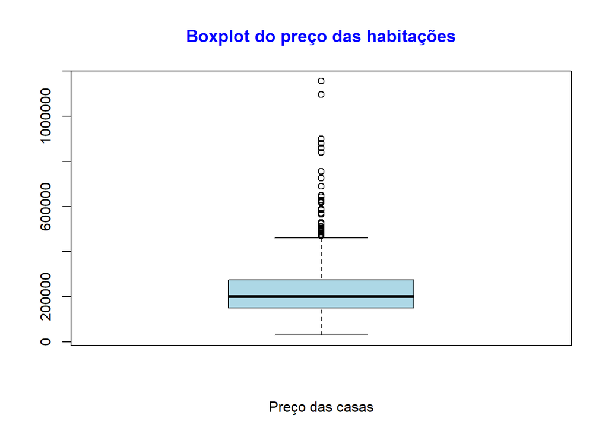

```r
#boxplot preço
boxplot(preco, xlab = 'Preço das casas', col = "lightblue", main="Boxplot do preço das habitações", col.main="blue")
```

Pela análise do *boxplot* percebe-se que a linha da mediana está mais próxima ao primeiro quartil, o que significa que os dados são assimétricos positivos. É possível também visualizar a presença de vários *outliers*.

### Análise da variável “agua”

Tal como se pode observar no gráfico de barras que se segue, o número de habitações próximas de zonas com água, isto é, junto a rios, mar, riachos e seus derivados é praticamente nulo. No entanto, existem duas habitações que se encontram situadas junto da água. Uma vez que em 1200 habitações, apenas duas delas apresentam esta característica, assume-se que se trata de uma medida muito pouco relevante para o caso de estudo.

[figure not shown]

```r
par(mfrow=c(1,2))

#Barplot preço vs agua
  rio <- c(2, 1198)
  bp <- barplot(rio,
  main = "Proximidade da água",
  xlab = "Número de habitações",
  ylab = "Proximidade da água",
  ylim = c(0,1500),
  names.arg = c("Yes", "No"),
  col = c("darkgreen", "darkred"),
  col.main = "blue",
  horiz = FALSE)
text(bp,rio+100,labels=as.character(rio))

#boxplot preço vs agua
boxplot(preco~agua, main="Preço vs Proximidade da água", xlab = "Proximidade da água", ylab = "Preço da habitação", col.main="blue", col=(c("darkred", "darkgreen")))
```

```r
tapply(preco,agua,summary)
```

```
## $No
##    Min. 1st Qu.  Median    Mean 3rd Qu.    Max.
##   30000  150000  199472  225997  275000 1155000
##
## $Yes
##    Min. 1st Qu.  Median    Mean 3rd Qu.    Max.
##  215270  228953  242635  242635  256318  270000
```

```r
t.test(preco~agua)
```

```
##
##  Welch Two Sample t-test
##
## data:  preco by agua
## t = -0.60336, df = 1.0311, p-value = 0.6519
## alternative hypothesis: true difference in means is not equal to 0
## 95 percent confidence interval:
##  -342996.2  309720.2
## sample estimates:
##  mean in group No mean in group Yes
##            225997            242635
```

### Análise da variável “idade”

No seguimento da análise em execução, apresenta-se a relação entre a variável dependente “preço” e a variável independente “idade”.

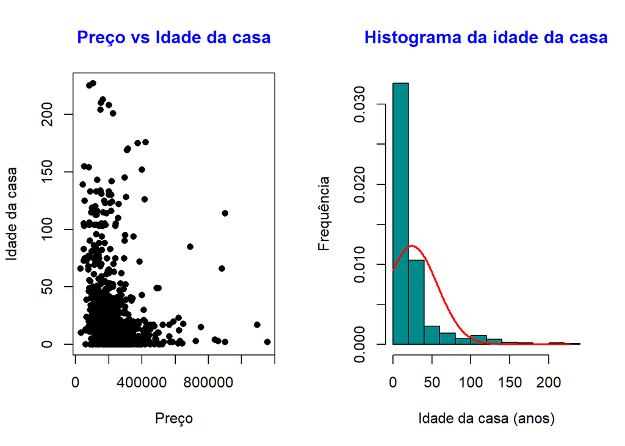

```r
par(mfrow=c(1,2))

#plot preço vs idadeCasa
plot(preco, idade, main = "Preço vs Idade da casa", col.main= "blue", xlab="Preço", ylab="Idade da casa", pch=16)

#histograma idade
h <- hist(idade, col="darkcyan", border="black", prob=TRUE, xlab="Idade da casa (anos)",
ylab="Frequência", col.main="blue", main="Histograma da idade da casa");
xfit<-seq(min(idade),max(idade))
yfit<-dnorm(xfit,mean=mean(idade),sd=sd(idade))
lines(xfit, yfit, col="red", lwd=2)
```

É notória a concentração de habitações a rondar os 100000 US$ e os 300000 US$ para idades entre os 0 e os 50 anos. Fora essa mancha, não existe propriamente uma relação entre as variáveis uma vez que, existem casas novas de preço bastante elevado (1200000 US$), mas também com valores mais acessíveis. Obviamente que nestes casos existem outros fatores a influenciar o valor final.

Pela análise do histograma, é percetível uma ligeira assimetria à direita, o que significa que a maior parte das casas têm menos de 50 anos.

### Análise da variável “areacasa”

Geralmente, considera-se que o preço das habitações é diretamente proporcional à área que a mesma ocupa. Existe uma tendência direta que garante que quanto maior a habitação, em *square feet*, maior será o seu valor.

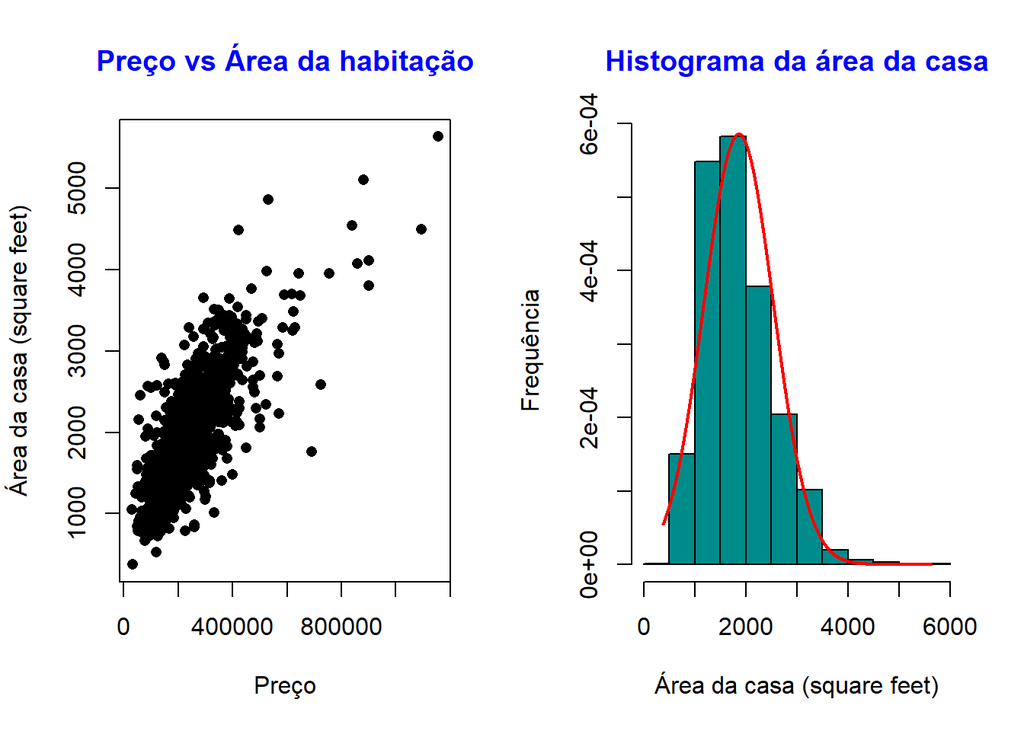

```r
par(mfrow=c(1,2))

#plot preco vs areaCasa
plot(preco, areacasa, main = "Preço vs Área da habitação", col.main= "blue", xlab="Preço", ylab="Área da casa (square feet)", pch=16)

h <- hist(areacasa, col="darkcyan", border="black", prob=TRUE, xlab="Área da casa (square feet)",
ylab="Frequência", col.main="blue", main="Histograma da área da casa");
xfit<-seq(min(areacasa),max(areacasa))
yfit<-dnorm(xfit,mean=mean(areacasa),sd=sd(areacasa))
lines(xfit, yfit, col="red", lwd=2)
```

Através da análise do histograma, percebe-se que há uma assimetria à direita, sendo que há mais casas concentradas abaixo de 2000 *square feet*.

### Análise da variável “arcentral”

[figure not shown]

```r
#Barplot preço vs Ar central
ar <- c(485, 715)
bar <- barplot(ar,
main = "Aquecimento central",
ylab = "Número de habitações",
xlab = "Aquecimento central",
ylim = c(0,1100),
names.arg = c("Yes", "No"),
col = c("darkgreen", "darkred"),
col.main="blue",
horiz = FALSE)
text(bar,ar+50,labels=as.character(ar))
```

Se antes de uma análise se tentasse perceber quais as habitações que seriam de valor mais elevado, seria óbvio que uma casa com aquecimento automaticamente seria mais cara, certo?

Através da aplicação do comando *tapply*:

```r
tapply(preco,arcentral,summary)
```

```
## $No
##    Min. 1st Qu.  Median    Mean 3rd Qu.    Max.
##   30000  130000  172500  188793  225000  880000
##
## $Yes
##    Min. 1st Qu.  Median    Mean 3rd Qu.    Max.
##   82200  190000  257500  280606  336000 1155000
```

```r
t.test(preco~arcentral)
```

```
##
##  Welch Two Sample t-test
##
## data:  preco by arcentral
## t = -13.317, df = 761.04, p-value < 2.2e-16
## alternative hypothesis: true difference in means is not equal to 0
## 95 percent confidence interval:
##  -105346.33  -78278.09
## sample estimates:
##  mean in group No mean in group Yes
##          188793.3          280605.5
```

Tal como a suposição acima referida, confirma-se: em média, habitações com aquecimento são 91813 dólares mais caras.

O *boxplot* que se segue permite visualizar que a reta da mediana em ambas as caixas está no centro do retângulo, logo têm distribuição simétrica. Existem *outliers* para as duas alternativas e pode-se verificar que uma casa com ar central apresenta maior variabilidade do que uma casa que não tem.

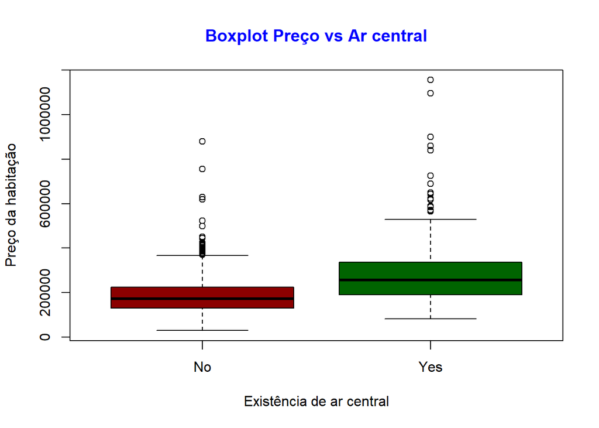

```r
#boxplot ar central
boxplot(preco~arcentral, main="Boxplot Preço vs Ar central", xlab = "Existência de ar central", ylab = "Preço da habitação", col.main="blue", col=(c("darkred", "darkgreen")))
```

### Análise da variável “tipocombustivel”

O gráfico de barras que se segue é muito útil para representar os dados discretos dos tipos de combustível que existem. Inicialmente, quando o grupo se deparou com o *dataset* original, verificou-se que dois tipos de combustíveis não traziam relevância para o modelo, podendo mesmo por em causa os seus resultados, uma vez que, em 1200 observações, apenas existiam 4 casas a utilizam estes tipos de combustível. Foi assim decidido remover os tipos de combustíveis designados por “Propane” e “Wood”.

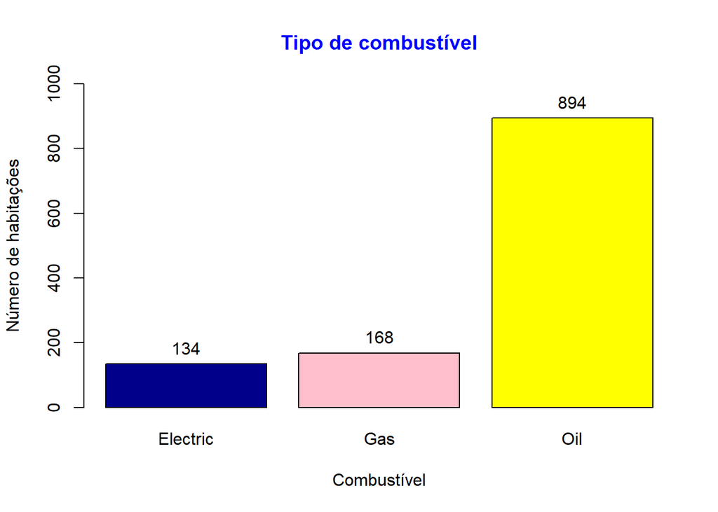

```r
#Barplot preço vs tipo combustivel
comb <- c(134, 168, 894)
bt <- barplot(comb,
main = "Tipo de combustível",
xlab = "Combustível",
ylab = "Número de habitações",
ylim = c(0,1000),
names.arg = c("Electric", "Gas","Oil"),
col= c("darkblue", "pink","yellow"),
col.main="blue",
horiz = FALSE)
text(bt,comb+50,labels=as.character(comb))
```

No final ficaram para análise três tipos de combustível, no qual o *Oil* é, claramente, o mais frequente.

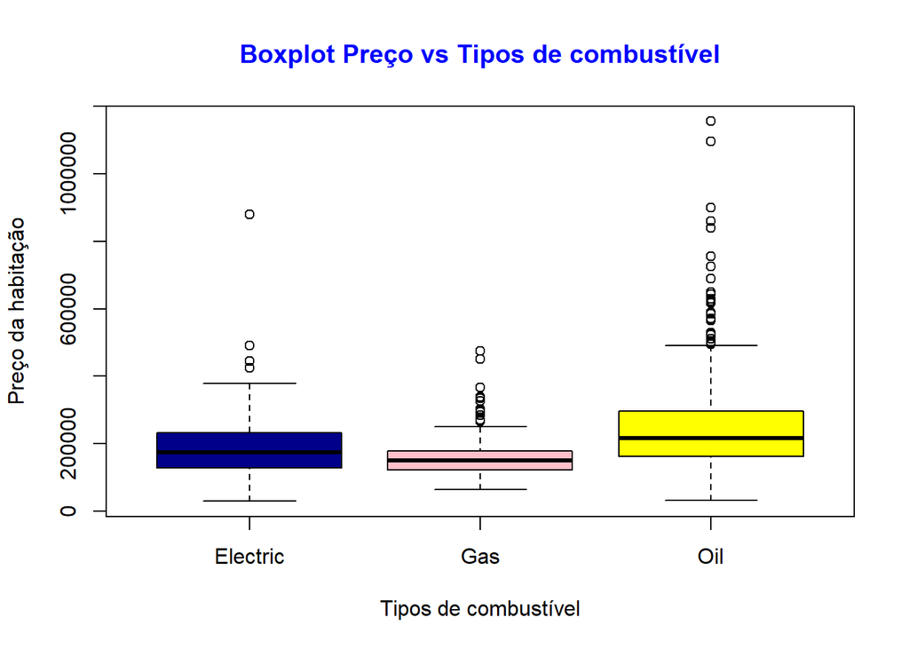

```r
#boxplot preço vs tipo combustivel
boxplot(preco~tipocombustivel, main="Boxplot Preço vs Tipos de combustível", xlab = "Tipos de combustível", ylab = "Preço da habitação", col.main="blue", col=(c("darkblue", "pink","yellow")))
```

```r
tapply(preco,tipocombustivel,summary)
```

```
## $Electric
##    Min. 1st Qu.  Median    Mean 3rd Qu.    Max.
##   30000  129250  174900  190620  231250  880000
##
## $Gas
##    Min. 1st Qu.  Median    Mean 3rd Qu.    Max.
##   65000  121920  149650  161434  177625  475000
##
## $Oil
##    Min. 1st Qu.  Median    Mean 3rd Qu.    Max.
##   33000  163625  216679  243470  295675 1155000
```

O *boxplot* acima representado mostra que, em média, é mais barato o *Gas*, seguido do tipo *Electric* e por fim o *Oil*. Nos três tipos estão evidentes a presença de *outliers*. O tipo *Oil* apresenta maior variabilidade do que os restantes tipos.

### Análise da variável “wcprivado”

A variável “wcprivado” mereceu destaque uma vez que foi considerada uma variável que influencia proporcionalmente o preço da casa. O *dataset* original continha valores a variar entre 1 e 5, no entanto observa-se no *boxplot* abaixo que apenas estão registados valores entre 1 e 3. O motivo pelo o qual apenas existem três valores é o facto de serem poucos os valores para 3, 4 e 5 casas de banho completas. Na realidade, a caixa de bigodes colorida a amarelo reflete os valores de 3, 4 e 5 casas de banho.

A forma como foi resolvida a situação foi através de uma variável auxiliar designada por “wcprivado_agre” que agrega valores maiores ou iguas a 3.

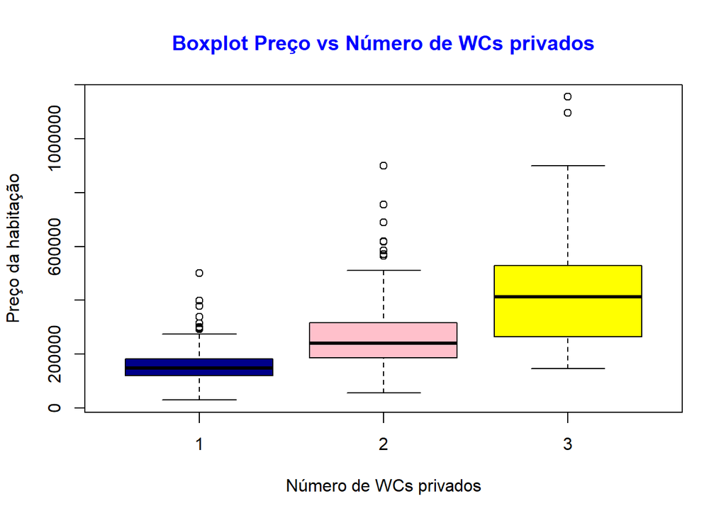

```r
#boxplot preço va wc privado
boxplot(preco~wcprivado, main="Boxplot Preço vs Número de WCs privados", xlab = "Número de WCs privados", ylab = "Preço da habitação", col.main="blue", col=(c("darkblue", "pink","yellow","orange","darkred")))
```

```r
tapply(preco,wcprivado,summary)
```

```
## $`1`
##    Min. 1st Qu.  Median    Mean 3rd Qu.    Max.
##   30000  120000  148200  154423  183000  501500
##
## $`2`
##    Min. 1st Qu.  Median    Mean 3rd Qu.    Max.
##   56000  187500  239900  256759  317172  900000
##
## $`3`
##    Min. 1st Qu.  Median    Mean 3rd Qu.    Max.
##  146900  267425  412500  449707  528750 1155000
```

De concluir que quanto maior o número de casas de banho completas maior o preço da casa. As casas com 3 ou mais casas de banho completas apresentam maior variabilidade do que as casas com 1 ou 2 casas de banho. Para todos os casos, é possível perceber a presença de vários *outliers*.

### Análise da variável “wcservico”

A seguir está presente o gráfico que permite saber o número de casas que têm casas de banho de serviço.

```r
tapply(preco,wcservico,summary)
```

```
## $`0`
##    Min. 1st Qu.  Median    Mean 3rd Qu.    Max.
##   30000  128000  162500  183234  217403  725000
##
## $`1`
##    Min. 1st Qu.  Median    Mean 3rd Qu.    Max.
##   44000  165900  220000  247771  304200 1155000
```

```r
t.test(preco~wcservico)
```

```
##
##  Welch Two Sample t-test
##
## data:  preco by wcservico
## t = -10.374, df = 1071.8, p-value < 2.2e-16
## alternative hypothesis: true difference in means is not equal to 0
## 95 percent confidence interval:
##  -76743.40 -52330.32
## sample estimates:
## mean in group 0 mean in group 1
##        183234.1        247770.9
```

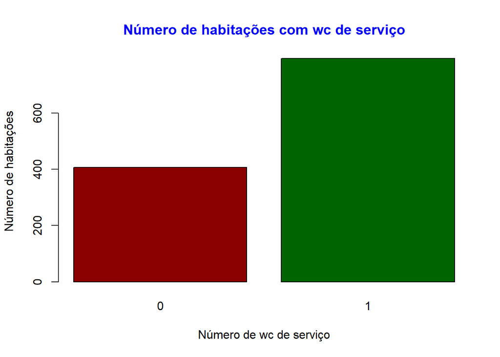

```r
wcserv <- c(406, 794)
barplot(wcserv,
main = "Número de habitações com wc de serviço",
ylab = "Número de habitações",
xlab = "Número de wc de serviço",
names.arg = c("0", "1"),
col = c("darkred", "darkgreen"), col.main="blue",
horiz = FALSE)
```

Existem 794 habitações com uma casa de banho de serviço, no entanto, cerca de 406 são habitações sem esta divisão. Em média, as casas que têm casa de banho de serviço são 64537 dólares mais caras do que as que não têm.

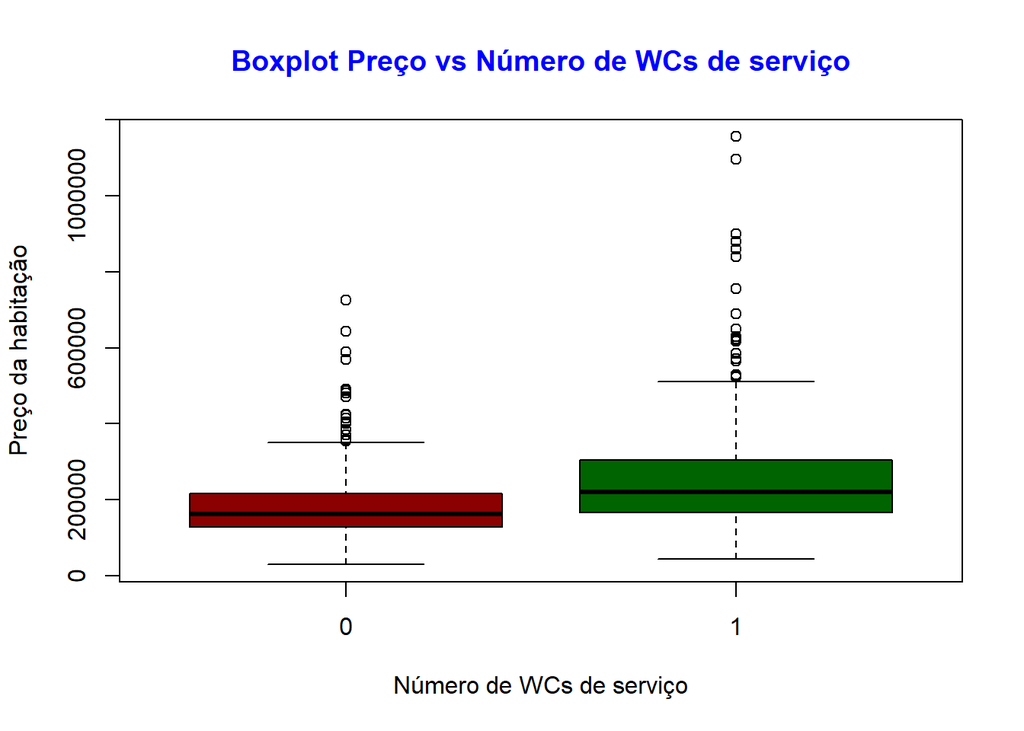

```r
#boxplot que relaciona o preço e as casas de banho de serviço
boxplot(preco~wcservico, main="Boxplot Preço vs Número de WCs de serviço", xlab = "Número de WCs de serviço", ylab = "Preço da habitação", col.main="blue", col=(c("darkred", "darkgreen")))
```

O *boxplot* põem em evidência aquilo que já tinha sido constatado acima, que habitações que possuem casas de banho de serviço são, em média, mais dispendiosas que habitações sem esta particularidade.

### Análise da variável “quartos”

Também a variável que especifica o número de quartos que uma habitação contém, foi alvo de uma análise. Após uma primeira observação, sentiu-se a necessidade de criar uma outra variável de agregação, que permitisse agregar habitações com número de quartos:

- Habitações com 1 ou 2 quartos -> 2
- Habitações com 3 quartos -> 3
- Habitações com 4 quartos -> 4
- Habitações com 5, 6 ou 7 quartos -> 5

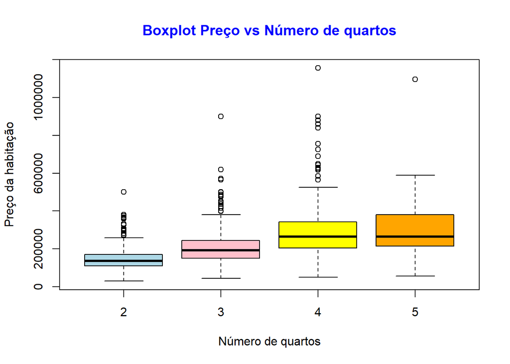

```r
#boxplot preço vs quartos
boxplot(preco~quartos, main="Boxplot Preço vs Número de quartos", xlab = "Número de quartos", ylab = "Preço da habitação", col.main="blue", col=(c("lightblue", "pink","yellow","orange")))
```

```r
tapply(preco,quartos,summary)
```

```
## $`2`
##    Min. 1st Qu.  Median    Mean 3rd Qu.    Max.
##   30000  110000  135900  150759  169683  501500
##
## $`3`
##    Min. 1st Qu.  Median    Mean 3rd Qu.    Max.
##   44000  151000  192650  210514  244913  900000
##
## $`4`
##    Min. 1st Qu.  Median    Mean 3rd Qu.    Max.
##   51000  205069  265000  288603  342324 1155000
##
## $`5`
##    Min. 1st Qu.  Median    Mean 3rd Qu.    Max.
##   56000  215500  264900  315290  380000 1095250
```

### Análise da variável “lareira”

Também nesta variável se sentiu a necessidade de criar uma outra variável de agregação para associar, na categoria “2”, habitações com 2 ou mais lareiras.

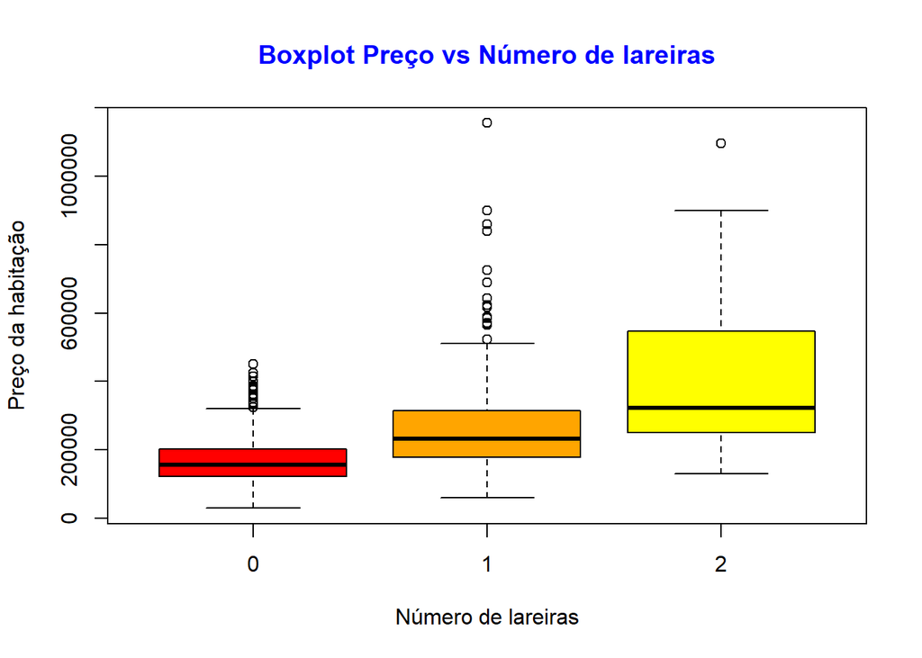

```r
#plot preço vs lareira
boxplot(preco~lareira, main="Boxplot Preço vs Número de lareiras", xlab = "Número de lareiras", ylab = "Preço da habitação", col.main="blue", col=(c("red","orange","yellow")))
```

```r
tapply(preco,lareira,summary)
```

```
## $`0`
##    Min. 1st Qu.  Median    Mean 3rd Qu.    Max.
##   30000  121680  157000  169824  202000  450000
##
## $`1`
##    Min. 1st Qu.  Median    Mean 3rd Qu.    Max.
##   60000  178750  232580  255593  315000 1155000
##
## $`2`
##    Min. 1st Qu.  Median    Mean 3rd Qu.    Max.
##  130000  252225  322450  418244  538750 1095250
```

Na generalidade dos casos correntes, é de esperar que uma casa com lareira será mais valorizada quando comparada com outra sem esta componente, e o mesmo será obviamente concluído quando comparamos uma habitação com duas ou mais lareiras em relação a uma habitação com uma lareira.

Com esta análise pretende-se evidenciar que quantas mais lareiras mais cara será a habitação. E de facto, a caixa a amarelo apresenta uma mediana, claramente, num nível superior que as restantes caixas.

### Matriz de correlação

Em estatística, correlação, dependência ou associação é qualquer relação estatística entre duas variáveis. A matriz de correlação mostra os valores de correlação de *Pearson*, que medem o grau de relação linear entre cada par de variáveis. Os valores de correlação variam entre -1 e +1, em que -1 significa uma correlação negativa entre as variáveis, ou seja, quando uma aumenta a outra diminui e 1 significa uma correlação positiva.

```r
library(corrplot)
matrix <- DadosTP[, c(3,6,8,11,12,13)]
#matrix
res<- cor(matrix)
round(res,2)
```

```
##                  Age Living Area Half Baths quartos_agr wcprivado_agre
## Age             1.00       -0.21      -0.23       -0.06          -0.32
## Living Area    -0.21        1.00       0.37        0.68           0.63
## Half Baths     -0.23        0.37       1.00        0.23           0.06
## quartos_agr    -0.06        0.68       0.23        1.00           0.46
## wcprivado_agre -0.32        0.63       0.06        0.46           1.00
## lareira_agre   -0.18        0.51       0.27        0.35           0.43
##                lareira_agre
## Age                   -0.18
## Living Area            0.51
## Half Baths             0.27
## quartos_agr            0.35
## wcprivado_agre         0.43
## lareira_agre           1.00
```

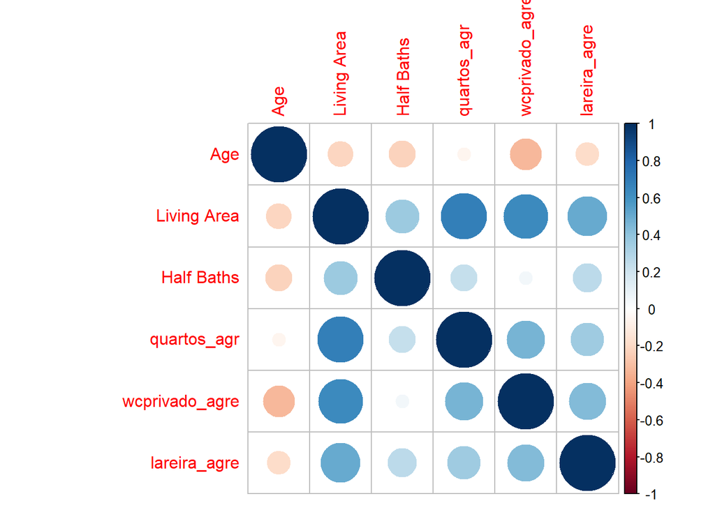

```r
corrplot(res, method = "circle")
```

Da imagem acima, conclui-se que não existe uma dependência suficientemente forte entre duas variáveis. De notar que os valores mais elevados (0.68) dizem respeito à relação entre a área da habitação e o número de quartos e ainda do número de casas de banho privativas em relação também com a área da casa com cerca de 0.63. No entanto, são valores pouco significativos para causarem alterações no modelo.

### Stepwise Regression (Regressão gradual)

A regressão gradual consiste em adicionar e remover iterativamente preditores no modelo preditivo, de forma a encontrar o subconjunto de variáveis que resultam no modelo com melhor desempenho, ou seja, o modelo que reduz o erro de previsão.

Existem 3 estratégias de regressão gradual:

- **Forward selection**: começa sem preditores no modelo e adiciona iterativamente os preditores que mais contribuem. Termina quando a melhoria não é mais estatisticamente significativa.
- **Backward selection**: começa com todos os preditores no modelo, removendo iterativamente os preditores que menos contribuem. Termina quando encontrar o modelo no qual todos os preditores são estatisticamente significativos.
- **Stepwise selection**: é uma combinação das duas seleções anteriores. Começa sem preditores e sequencialmente adiciona os preditores que mais contribuem. Depois de adicionar cada variável nova, remove as variáveis que já não proporcionam melhorias ao modelo.

A função do R utilizado neste modelo é o “stepAIC” que escolhe o melhor modelo com base no AIC (*Akaike’s Information Criteria*). Este critério estima a qualidade de cada modelo criado para os dados, em relação a cada um dos outros modelos. A opção *direction* permite escolher qual das estratégias aplicar, *backward*, *forward* ou *both* (as duas em conjunto). No final, permite saber qual o melhor modelo.

```r
#Construção do modelo
library(tidyverse)
library(caret)
library(leaps)
library(tidyr)
library(dplyr)
library(MASS)
#ajuste completo do modelo
full.model <- lm (preco ~ idade + arcentral + tipocombustivel + areacasa + wcprivado + wcservico + quartos + lareira, data = DadosTP)
summary(full.model)
```

```
##
## Call:
## lm(formula = preco ~ idade + arcentral + tipocombustivel + areacasa +
##     wcprivado + wcservico + quartos + lareira, data = DadosTP)
##
## Residuals:
##     Min      1Q  Median      3Q     Max
## -271836  -40639   -4838   32280  507754
##
## Coefficients:
##                     Estimate Std. Error t value Pr(>|t|)
## (Intercept)          3906.67   11977.76   0.326    0.744
## idade                  46.44      72.08   0.644    0.520
## arcentralYes        24965.80    4667.35   5.349 1.06e-07 ***
## tipocombustivelGas   4043.45    8633.13   0.468    0.640
## tipocombustivelOil   7556.77    6966.71   1.085    0.278
## areacasa              136.80       5.16  26.509  < 2e-16 ***
## wcprivado           23030.46    5200.89   4.428 1.04e-05 ***
## wcservico           -6633.69    4984.75  -1.331    0.184
## quartos            -27146.31    3668.38  -7.400 2.57e-13 ***
## lareira              4600.52    4546.69   1.012    0.312
## ---
## Signif. codes:  0 '***' 0.001 '**' 0.01 '*' 0.05 '.' 0.1 ' ' 1
##
## Residual standard error: 69800 on 1186 degrees of freedom
## Multiple R-squared:  0.6491, Adjusted R-squared:  0.6465
## F-statistic: 243.8 on 9 and 1186 DF,  p-value: < 2.2e-16
```

```r
#método both
step.model <- stepAIC(full.model, direction = "both",
                      trace = FALSE)
summary(step.model)
```

```
##
## Call:
## lm(formula = preco ~ arcentral + areacasa + wcprivado + quartos,
##     data = DadosTP)
##
## Residuals:
##     Min      1Q  Median      3Q     Max
## -262713  -40240   -4846   31752  511785
##
## Coefficients:
##                Estimate Std. Error t value Pr(>|t|)
## (Intercept)    6188.966   9008.996   0.687    0.492
## arcentralYes  25432.076   4452.239   5.712 1.41e-08 ***
## areacasa        135.521      4.749  28.536  < 2e-16 ***
## wcprivado     25102.747   4718.980   5.320 1.24e-07 ***
## quartos      -26418.261   3602.759  -7.333 4.15e-13 ***
## ---
## Signif. codes:  0 '***' 0.001 '**' 0.01 '*' 0.05 '.' 0.1 ' ' 1
##
## Residual standard error: 69770 on 1191 degrees of freedom
## Multiple R-squared:  0.6479, Adjusted R-squared:  0.6467
## F-statistic: 547.9 on 4 and 1191 DF,  p-value: < 2.2e-16
```

```r
#método backward
step.modelb <- stepAIC(full.model, direction = "backward",
                      trace = FALSE)
summary(step.modelb)
```

```
##
## Call:
## lm(formula = preco ~ arcentral + areacasa + wcprivado + quartos,
##     data = DadosTP)
##
## Residuals:
##     Min      1Q  Median      3Q     Max
## -262713  -40240   -4846   31752  511785
##
## Coefficients:
##                Estimate Std. Error t value Pr(>|t|)
## (Intercept)    6188.966   9008.996   0.687    0.492
## arcentralYes  25432.076   4452.239   5.712 1.41e-08 ***
## areacasa        135.521      4.749  28.536  < 2e-16 ***
## wcprivado     25102.747   4718.980   5.320 1.24e-07 ***
## quartos      -26418.261   3602.759  -7.333 4.15e-13 ***
## ---
## Signif. codes:  0 '***' 0.001 '**' 0.01 '*' 0.05 '.' 0.1 ' ' 1
##
## Residual standard error: 69770 on 1191 degrees of freedom
## Multiple R-squared:  0.6479, Adjusted R-squared:  0.6467
## F-statistic: 547.9 on 4 and 1191 DF,  p-value: < 2.2e-16
```

```r
#método forward
step.modelf <- stepAIC(full.model, direction = "forward",
                       trace = FALSE)
summary(step.modelf)
```

```
##
## Call:
## lm(formula = preco ~ idade + arcentral + tipocombustivel + areacasa +
##     wcprivado + wcservico + quartos + lareira, data = DadosTP)
##
## Residuals:
##     Min      1Q  Median      3Q     Max
## -271836  -40639   -4838   32280  507754
##
## Coefficients:
##                     Estimate Std. Error t value Pr(>|t|)
## (Intercept)          3906.67   11977.76   0.326    0.744
## idade                  46.44      72.08   0.644    0.520
## arcentralYes        24965.80    4667.35   5.349 1.06e-07 ***
## tipocombustivelGas   4043.45    8633.13   0.468    0.640
## tipocombustivelOil   7556.77    6966.71   1.085    0.278
## areacasa              136.80       5.16  26.509  < 2e-16 ***
## wcprivado           23030.46    5200.89   4.428 1.04e-05 ***
## wcservico           -6633.69    4984.75  -1.331    0.184
## quartos            -27146.31    3668.38  -7.400 2.57e-13 ***
## lareira              4600.52    4546.69   1.012    0.312
## ---
## Signif. codes:  0 '***' 0.001 '**' 0.01 '*' 0.05 '.' 0.1 ' ' 1
##
## Residual standard error: 69800 on 1186 degrees of freedom
## Multiple R-squared:  0.6491, Adjusted R-squared:  0.6465
## F-statistic: 243.8 on 9 and 1186 DF,  p-value: < 2.2e-16
```

```r
#verificar qual o que tem menor AIC
#AIC(step.model)
AIC(step.modelb)
```

```
## [1] 30079.08
```

```r
AIC(step.modelf)
```

```
## [1] 30084.88
```

A função “regsubsets” tem um parâmetro “nvmax” que especifica o número máximo de preditores para incorporar no modelo. Retorna vários modelos com diferentes tamanhos até “nvmax”. Tem de se comparar os vários modelos de forma a escolher o melhor. Esta função tem a opção “method” que permite escolher *forward*, *backward* e *seqrep* (que é uma combinação das seleções *forward* e *backward*).

```r
models <- regsubsets(preco ~ idade + arcentral +tipocombustivel+ areacasa + wcprivado + wcservico + quartos + lareira, data = DadosTP, nvmax = 9, method = "seqrep")
summary(models)
```

```
## Subset selection object
## Call: regsubsets.formula(preco ~ idade + arcentral + tipocombustivel +
##     areacasa + wcprivado + wcservico + quartos + lareira, data = DadosTP,
##     nvmax = 9, method = "seqrep")
## 9 Variables  (and intercept)
##                    Forced in Forced out
## idade                  FALSE      FALSE
## arcentralYes           FALSE      FALSE
## tipocombustivelGas     FALSE      FALSE
## tipocombustivelOil     FALSE      FALSE
## areacasa               FALSE      FALSE
## wcprivado              FALSE      FALSE
## wcservico              FALSE      FALSE
## quartos                FALSE      FALSE
## lareira                FALSE      FALSE
## 1 subsets of each size up to 9
## Selection Algorithm: 'sequential replacement'
##          idade arcentralYes tipocombustivelGas tipocombustivelOil areacasa
## 1  ( 1 ) " "   " "          " "                " "                "*"
## 2  ( 1 ) " "   " "          " "                " "                "*"
## 3  ( 1 ) " "   "*"          " "                " "                "*"
## 4  ( 1 ) " "   "*"          " "                " "                "*"
## 5  ( 1 ) " "   "*"          " "                " "                "*"
## 6  ( 1 ) " "   "*"          " "                " "                "*"
## 7  ( 1 ) " "   "*"          " "                "*"                "*"
## 8  ( 1 ) "*"   "*"          "*"                "*"                "*"
## 9  ( 1 ) "*"   "*"          "*"                "*"                "*"
##          wcprivado wcservico quartos lareira
## 1  ( 1 ) " "       " "       " "     " "
## 2  ( 1 ) " "       " "       "*"     " "
## 3  ( 1 ) " "       " "       "*"     " "
## 4  ( 1 ) "*"       " "       "*"     " "
## 5  ( 1 ) "*"       "*"       "*"     " "
## 6  ( 1 ) "*"       "*"       "*"     "*"
## 7  ( 1 ) "*"       "*"       "*"     "*"
## 8  ( 1 ) "*"       "*"       "*"     " "
## 9  ( 1 ) "*"       "*"       "*"     "*"
```

```r
# Set seed
set.seed(123)
# Set up repeated k-fold cross-validation
train.control <- trainControl(method = "cv", number = 10)
# Train the model
step.model <- train(`Sale Price` ~., data =DadosTP,
                    method = "leapBackward",
                    tuneGrid = data.frame(nvmax = 1:8),
                    trControl = train.control)

# precisão do modelo - escolher o menor erro médio de previsão e MAE, R squared quanto maior melhor
step.model$results
```

```
##   nvmax     RMSE  Rsquared      MAE    RMSESD RsquaredSD    MAESD
## 1     1 73139.81 0.6108847 50311.93  9978.864 0.08134661 4695.372
## 2     2 72255.20 0.6229323 50249.29  9704.207 0.08056855 4659.819
## 3     3 70026.07 0.6430664 49179.99  9587.031 0.08499824 4481.016
## 4     4 69242.37 0.6514295 48598.27  9433.596 0.07824334 4370.458
## 5     5 70138.39 0.6409680 48733.83 10498.299 0.06788546 4697.275
## 6     6 70187.75 0.6406623 48683.52 10516.564 0.06756056 4427.111
## 7     7 69764.85 0.6424136 48412.40  9848.215 0.06804273 4256.689
## 8     8 69813.83 0.6417018 48498.84  9768.842 0.06673371 4117.935
```

A função “train” tem uma opção “method” que permite escolher um dos seguintes valores:

- **leapBackward**: para a seleção “backward”
- **leapForward**: para a seleção “forward”
- **leapSeq**: para a seleção “stepwise”

Utiliza-se a *10-fold cross validation* para estimar o erro médio de previsão (RMSE). O RMSE é usado para comparar os 8 melhores modelos e escolher o melhor, que é o modelo que minimiza o erro médio de previsão.

O Rsquared indica a correlação entre o resultado obtido e os valores previstos pelo modelo. Quanto maior o Rsquared, melhor o modelo.

O modelo com 4 variáveis é aquele que simultaneamente tem o menor RMSE e o maior Rsquared, sendo assim considerado o melhor modelo.

```r
#melhor modelo
step.model$bestTune
```

```
##   nvmax
## 4     4
```

```r
#coeficientes finais do modelo
coef(step.model$finalModel, 4)
```

```
##      (Intercept) `Central Air`Yes    `Living Area`     `Full Baths`
##        3659.0150       24854.0978         133.4255       29012.6773
##         Bedrooms
##      -26426.3844
```

```r
summary(step.model$finalModel)
```

```
## Subset selection object
## 13 Variables  (and intercept)
##                  Forced in Forced out
## WaterfrontYes        FALSE      FALSE
## Age                  FALSE      FALSE
## `Central Air`Yes     FALSE      FALSE
## `Fuel Type`Gas       FALSE      FALSE
## `Fuel Type`Oil       FALSE      FALSE
## `Living Area`        FALSE      FALSE
## `Full Baths`         FALSE      FALSE
## `Half Baths`         FALSE      FALSE
## Bedrooms             FALSE      FALSE
## Fireplaces           FALSE      FALSE
## quartos_agr          FALSE      FALSE
## wcprivado_agre       FALSE      FALSE
## lareira_agre         FALSE      FALSE
## 1 subsets of each size up to 4
## Selection Algorithm: backward
##          WaterfrontYes Age `Central Air`Yes `Fuel Type`Gas `Fuel Type`Oil
## 1  ( 1 ) " "           " " " "              " "            " "
## 2  ( 1 ) " "           " " " "              " "            " "
## 3  ( 1 ) " "           " " " "              " "            " "
## 4  ( 1 ) " "           " " "*"              " "            " "
##          `Living Area` `Full Baths` `Half Baths` Bedrooms Fireplaces
## 1  ( 1 ) "*"           " "          " "          " "      " "
## 2  ( 1 ) "*"           " "          " "          "*"      " "
## 3  ( 1 ) "*"           "*"          " "          "*"      " "
## 4  ( 1 ) "*"           "*"          " "          "*"      " "
##          quartos_agr wcprivado_agre lareira_agre
## 1  ( 1 ) " "         " "            " "
## 2  ( 1 ) " "         " "            " "
## 3  ( 1 ) " "         " "            " "
## 4  ( 1 ) " "         " "            " "
```

Interpretação dos coeficientes obtidos:

## Teste F-ANOVA

```r
#guardar em model os coeficientes do stepwise que vamos usar
model=lm(preco ~ arcentral + areacasa + wcprivado + quartos)
summary(model)
```

```
##
## Call:
## lm(formula = preco ~ arcentral + areacasa + wcprivado + quartos)
##
## Residuals:
##     Min      1Q  Median      3Q     Max
## -262713  -40240   -4846   31752  511785
##
## Coefficients:
##                Estimate Std. Error t value Pr(>|t|)
## (Intercept)    6188.966   9008.996   0.687    0.492
## arcentralYes  25432.076   4452.239   5.712 1.41e-08 ***
## areacasa        135.521      4.749  28.536  < 2e-16 ***
## wcprivado     25102.747   4718.980   5.320 1.24e-07 ***
## quartos      -26418.261   3602.759  -7.333 4.15e-13 ***
## ---
## Signif. codes:  0 '***' 0.001 '**' 0.01 '*' 0.05 '.' 0.1 ' ' 1
##
## Residual standard error: 69770 on 1191 degrees of freedom
## Multiple R-squared:  0.6479, Adjusted R-squared:  0.6467
## F-statistic: 547.9 on 4 and 1191 DF,  p-value: < 2.2e-16
```

Para efetuar o teste ANOVA são utilizadas as seguintes hipóteses:

- H0: o modelo de regressão não é válido
- H1: o modelo de regressão é válido

Se o valor de p-value < 0.05, rejeitar a hipótese nula, logo o modelo é válido.

Neste modelo, o p-value = 2.2e-16, logo a hipótese nula é rejeitada, isto significa que o o modelo é válido. Quanto ao “Multiple R-squared”, este é de 0.6479, ou seja, 64,79% da variação do resultado é explicado pela variação das variáveis utilizadas no modelo.

# Análise dos Resíduos

A análise de resíduos é uma parte importante da etapa de ajuste de modelos de regressão linear. Nesta fase deve-se verificar os pressupostos do modelo com base na análise dos resíduos: normalidade, homocedasticidade, independência e média zero.

## Condições assumidas pelo modelo

- **Normalidade dos resíduos:** os resíduos gerados pelo ajuste da reta seguem uma distribuição normal
- **Homocedasticidade:** é necessário que a variância de Y seja constante para todos os valores de X
- **Independência:** É necessário que não exista estrutura de dependência entre os dados, para que os resíduos sejam independentes e identicamente distribuídos.
- **Média zero** é um dos pressupostos assumidos na análise de regressão linear

Desta forma é necessário avaliar as suposições acima referidas através da análise de resíduos, vista gráficamente de seguida.

A linha seguinte mostra os resíduos do modelo. Os resíduos são a diferença entre os valores reais de resposta observados e os valores de resposta que o modelo previu. A análise exploratória dos resíduos é uma forma de validar o modelo. Para saber o quão bem o modelo se ajusta aos dados deve-se procurar uma distribuição simétrica entre esses pontos no valor da média zero, caso que se verifica neste modelo.

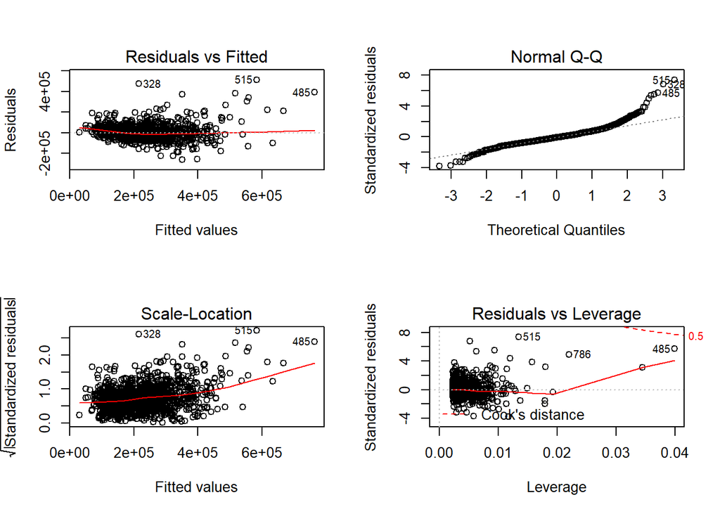

```r
## Avaliação dos resíduos
windows()
par(mfrow=c(2,2))
plot(model)
```

```r
summary(model$residuals)
```

```
##    Min. 1st Qu.  Median    Mean 3rd Qu.    Max.
## -262713  -40240   -4846       0   31752  511785
```

No primeiro gráfico, observam-se os resíduos em função dos valores estimados. Esse gráfico é importante para a verificação de possíveis padrões não aleatórios, heterocedasticidade, presença de *outliers* e pontos influentes. O padrão que indica bom ajuste é o de pontos dispersos aleatóriamente e a linha de tendência aproximadamente constante em torno de zero.

O segundo gráfico permite avaliar a pressuposição de normalidade dos resíduos. A linha da diagonal a tracejado representa a distribuição normal e os pontos a distribuição dos resíduos observada. Os pontos dispersos aleatoriamente, nas proximidades da linha identidade, indicam normalidade.

O terceiro gráfico é uma alternativa ao primeiro, baseado nos resíduos padronizados. Pode ser avaliado de forma semelhante ao primeiro, observando a aleatoriedade e amplitude desta vez dos resíduos padronizados.

O último permite visualizar as distâncias de Cook das observações, uma medida que influencia a presença de *outliers* quando possui valor maior do que 1. Observações com valores elevados para essa medida devem ser verificadas.

```r
residuals(model)
```

[output not shown]

[output cut: 425 more lines]

[output not shown]

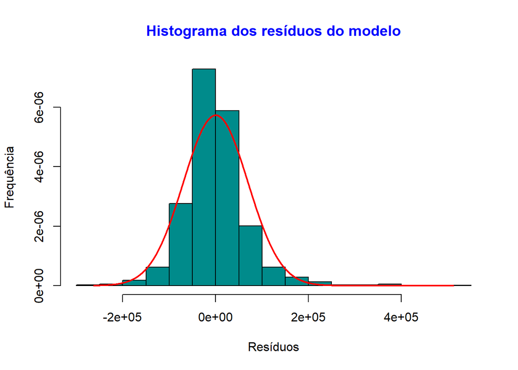

```r
#histograma dos resíduos
h <- hist(residuals(model), col="darkcyan", border="black", prob=TRUE, xlab="Resíduos",
ylab="Frequência", col.main="blue", main="Histograma dos resíduos do modelo");
xfit<-seq(min(residuals(model)),max(residuals(model)))
yfit<-dnorm(xfit,mean=mean(residuals(model)),sd=sd(residuals(model)))
lines(xfit, yfit, col="red", lwd=2)
```

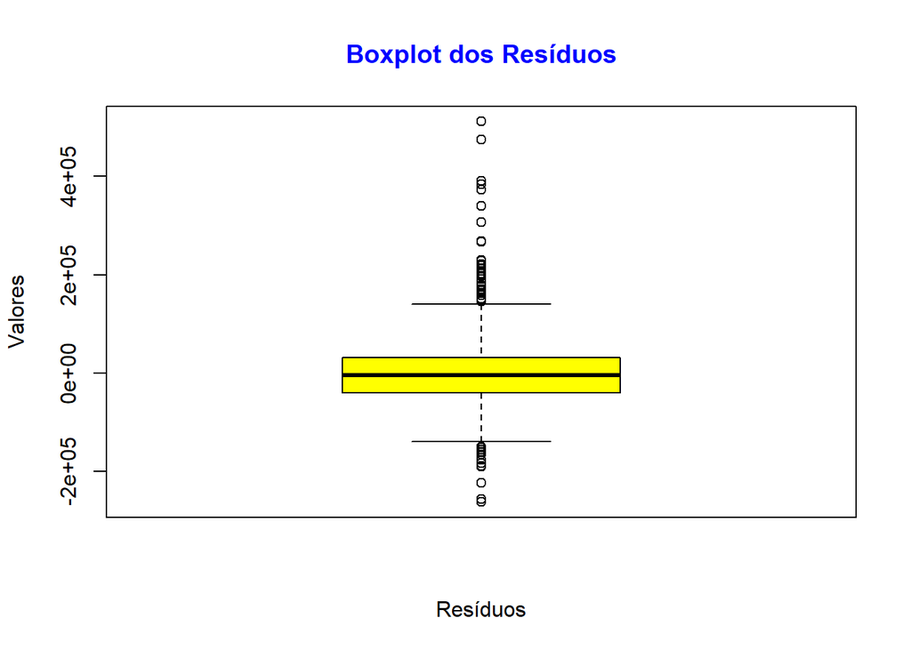

```r
#boxplot dos resíduos
boxplot(model$residuals, main="Boxplot dos Resíduos", xlab = "Resíduos", ylab = "Valores", col.main="blue", col="yellow")
```

O *boxplot* apresentado acima é uma forma de análise descritiva para avaliação dos resíduos. Neste caso, verifica-se uma aparente simetria dos resíduos e a presença de vários valores atípicos.

#Testes à normalidade

### One-sample Kolmogorov-Smirnov test

As hipóteses do teste são:

- H0: os resíduos seguem distribuição normal
- H1: os resíduos não seguem uma distribuição normal

A hipótese nula não é rejeitada se o p-value > 0.05.

```r
ks.test(model$residuals, "pnorm", mean(model$residuals), sd(model$residuals))
```

```
##
##  One-sample Kolmogorov-Smirnov test
##
## data:  model$residuals
## D = 0.084394, p-value = 7.981e-08
## alternative hypothesis: two-sided
```

Pelo teste do Kolmogorov-Smirnov, o p-value = 7.981e-08, ou seja, é menor do 0.05. Assim, a hipótese nula é rejeitada, logo os resíduos não seguem distribuição normal.

### Shapiro-Wilk normality test

O teste de de Shapiro-Wilk é um teste utilizado para verificar se a distribuição de probabilidade associada a um conjunto de dados pode ser aproximada pela distribuição normal. As hipóteses do teste são:

- H0: os resíduos seguem distribuição normal
- H1: os resíduos não seguem uma distribuição normal

A hipótese nula não é rejeitada se o p-value > 0.05.

```r
shapiro.test(model$residuals)
```

```
##
##  Shapiro-Wilk normality test
##
## data:  model$residuals
## W = 0.90625, p-value < 2.2e-16
```

Pelo teste Shapiro-Wilk, o p-value = 2.2e-16, logo a hipótese nula é rejeitada e os resíduos não seguem distribuição normal.

### Teste T-Student

O teste T-Student permite testar se a média dos resíduos é nula contra a hiótese de não ser. As hipóteses do teste são:

- H0: a média dos resíduos é zero
- H1: a média dos resíduos não é zero

```r
t.test(model$residuals, mu=0, alternative = "two.sided")
```

```
##
##  One Sample t-test
##
## data:  model$residuals
## t = 5.2714e-16, df = 1195, p-value = 1
## alternative hypothesis: true mean is not equal to 0
## 95 percent confidence interval:
##  -3951.689  3951.689
## sample estimates:
##    mean of x
## 1.061739e-12
```

Como o p-value = 1, a hipótese nula não é rejeitada.

## Previsões

- Habitação 1:
  1. Ar central: Sim
  2. Área da casa: 1000 *square feet*
  3. Casas de banho completas: 2
  4. Quartos: 3
- Habitação 2:
  1. Ar central: Não
  2. Área da casa: 2000 *square feet*
  3. Casas de banho completas: 3
  4. Quartos: 6

Qual o preço médio (ou esperado) da casa, em dólares, correspondentes às habitações 1 e 2?

Obtendo assim as estimativas pontuais:

```r
#habitação 1
predict(model, list(arcentral="Yes", areacasa=1000, wcprivado=2, quartos=3))
```

```
##        1
## 138093.2
```

```r
#habitação 2
predict(model, list(arcentral="No", areacasa=2000, wcprivado=3, quartos=6))
```

```
##        1
## 194030.6
```

Respondendo à pergunta, a previsão é que a casa custe 138093.2 dólares para o caso da habitação 1 e 194030.6 dólares para o caso da habitação 2.